# Chapter 8 Reading and Writing Files

# 8.1 R-Ready Data Sets

## 8.1.1 Built-in Data Sets

`datasets` library gives a set of built-in datasets available in base-r

Can get a summary of the data sets with:

```r
library(help="datasets")
```

Can access like any other data frame variable

```r
ChickWeight[1:15, ]
```

|  | weight | Time | Chick | Diet |
| --- | --- | --- | --- | --- |
| 1 | 42 | 0 | 1 | 1 |
| 2 | 51 | 2 | 1 | 1 |
| 3 | 59 | 4 | 1 | 1 |
| 4 | 64 | 6 | 1 | 1 |
| 5 | 76 | 8 | 1 | 1 |
| 6 | 93 | 10 | 1 | 1 |
| 7 | 106 | 12 | 1 | 1 |
| 8 | 125 | 14 | 1 | 1 |
| 9 | 149 | 16 | 1 | 1 |
| 10 | 171 | 18 | 1 | 1 |

[output cut: 5 more lines]

## 8.1.2 Contributed Data Sets

Many other data set libraries available, i.e. `tseries` package, first:

`install.packages("tseries")`

```r
library("tseries")
```

First have to load data into workspace, then can access

```r
data(ice.river)
ice.river[1:5, ]
```

```
     flow.vat flow.jok prec temp
[1,]     16.1     30.2  8.1  0.9
[2,]     19.2     29.0  4.4  1.6
[3,]     14.5     28.4  7.0  0.1
[4,]     11.0     27.8  0.0  0.6
[5,]     13.6     27.8  0.0  2.0
```

# 8.2 Reading in External Data Files

## 8.2.1 The Table Format

File created in a tabular format, called *`mydatafile.txt`*

Can then load file in using `read.table()`

```r
my_data_file <- read.table(
                            file='../data/mydatafile.txt',
                            header=TRUE,
                            sep=" ",
                            na.strings="*",
                            stringsAsFactors=FALSE
                        )
my_data_file
```

| person | age | sex | funny | age.mon |
| --- | --- | --- | --- | --- |
| Peter | NA | M | High | 504 |
| Lois | 40 | F | NA | 480 |
| Meg | 17 | F | Low | 204 |
| Chris | 14 | M | Med | 168 |
| Stewie | 1 | M | High | NA |
| Brian | NA | M | Med | NA |

`file` keyword will use linux style file paths, can use `list.files()` like `ls`

```r
list.files("../data")
```

```
[1] "mydatafile.txt"
```

`file.choose()` will open a file explorer, and return the correctly formatted file path string

```r
file.choose()
```

```
[1] "C:\\Users\\jagma\\Documents\\Coding\\RProjects\\BookOfR\\PartI[Language]\\data\\mydatafile.txt"
```

Can then pass to `read.table()`, and work with the data

```r
my_data_file$sex <- as.factor(my_data_file$sex)
my_data_file$funny <- factor(
                            x=my_data_file$funny,
                            levels=c("Low", "Med", "High")
                            )
```

## 8.2.2 Spreadsheet Workbooks

Created spreadsheet in *`spreadsheetfile.xlsx`* then saved to *`shreadsheetfile.csv`*

Then use `read.csv()` to load data in

```r
spread <- read.csv(
                file='../data/spreadsheetfile.csv',
                header=FALSE,
                stringsAsFactors=TRUE
                )
spread
```

| V1 | V2 | V3 |
| --- | --- | --- |
| 55 | 161 | female |
| 85 | 185 | male |
| 75 | 174 | male |
| 42 | 154 | female |
| 93 | 188 | male |
| 63 | 178 | male |
| 58 | 170 | female |
| 75 | 167 | male |
| 89 | 181 | male |
| 67 | 178 | female |

## 8.2.3 Web-Based Files

Can read in data from URLs with `read.table()`

```r
dia.url <- "https://www.amstat.org/publications/jse/v9n2/4Cdata.txt"
diamonds <- read.table(dia.url)
```

```r
names(diamonds) <- c("Carat", "Colour", "Clarity", "Cert", "Price")
diamonds[1:5, ]
```

|  | Carat | Colour | Clarity | Cert | Price |
| --- | --- | --- | --- | --- | --- |
| 1 | 0.30 | D | VS2 | GIA | 1302 |
| 2 | 0.30 | E | VS1 | GIA | 1510 |
| 3 | 0.30 | G | VVS1 | GIA | 1510 |
| 4 | 0.30 | G | VS1 | GIA | 1260 |
| 5 | 0.31 | D | VS1 | GIA | 1641 |

## 8.2.4 Other File Formats

R can work with many other file types, and third party packages can make this even easier

# 8.3 Writing Out Data Files and Plots

## 8.3.1 Data Sets

Write data to file using `write.table()`

```r
write.table(
            x=my_data_file,
            file="../output/somenewfile.txt",
            sep="@",
            na="??",
            quote=FALSE,
            row.names=FALSE
            )
```

`write.csv()` is also available, `file.choose()` is not usually used here

## 8.3.2 Plots and Graphics Files

Create *.jpeg* files using the `jpeg()` object graphics device

```r
jpeg(
    filename="../output/myjpegplot.jpeg",
    width=600,
    height=600
    )
plot(
    1:5, 6:10,
    ylab="a nice ylab",
    xlab="here's an xlab",
    main="a saved .jpeg plot"
    )
points(1:5, 10:6, cex=2, pch=4, col=2)
dev.off()
```

Need to call `dev.off()` to finish plot and write file

Create *.pdf* with `pdf()` objects

```r
pdf(file="../output/mypdfplot.pdf", width=5, height=5)
plot(
    1:5, 6:10,
    ylab="a nice ylab",
    xlab="here's an xlab",
    main="a saved .pdf plot"
    )
points(1:5, 10:6, cex=2, pch=4, col=2)
dev.off()
```

Can use `ggplot2` plots `ggsave()` function

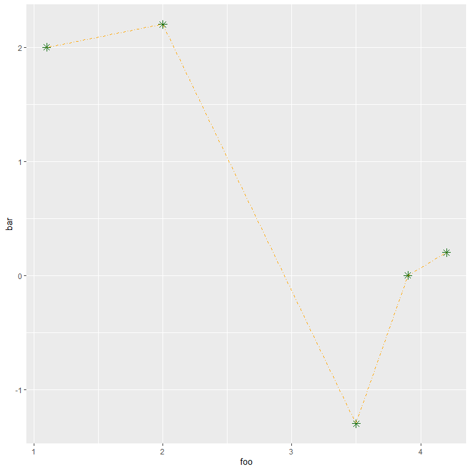

```r
library("ggplot2")

foo <- c(1.1, 2, 3.5, 3.9, 4.2)
bar <- c(2, 2.2, -1.3, 0, 0.2)

(
qplot(foo, bar, geom='blank')
+ geom_point(size=3, shape=8, color="darkgreen")
+ geom_line(color="orange", linetype=4)
)
```

```r
ggsave(filename='../output/mypngplot.png')
```

# 8.4 Ad-Hoc Object Read/Write Operations

Can read/write R-objects to files

```r
somelist <- list(
                foo=c(5, 2, 45),
                bar=matrix(
                            data=c(T, T, F, F, F, F, T, F, T),
                            nrow=3,
                            ncol=3
                            ),
                baz=factor(
                            c(1, 2, 2, 3, 1, 1, 3),
                            levels=1:3,
                            ordered=TRUE
                        )
                )
somelist
```

```
$foo
[1]  5  2 45

$bar
      [,1]  [,2]  [,3]
[1,]  TRUE FALSE  TRUE
[2,]  TRUE FALSE FALSE
[3,] FALSE FALSE  TRUE

$baz
[1] 1 2 2 3 1 1 3
Levels: 1 < 2 < 3
```

Use of `dput()` to write R-objects

```r
dput(x=somelist, file='../output/myRobject.txt')
```

Then use `dget()` to retrieve object from file

```r
new_object <- dget(file='../output/myRobject.txt')
new_object
```

```
$foo
[1]  5  2 45

$bar
      [,1]  [,2]  [,3]
[1,]  TRUE FALSE  TRUE
[2,]  TRUE FALSE FALSE
[3,] FALSE FALSE  TRUE

$baz
[1] 1 2 2 3 1 1 3
Levels: 1 < 2 < 3
```

## 8.1 Exercises

### (a) Using the built-in data set `quakes`:

#### (i) Select only the records where the `mag` is greater than or equal to 5, then write it to a table-format file called *`q5.txt`*, using a delimiter of `!` and now row names

```r
q5 <- quakes[quakes$mag >= 5, ]
write.table(
            q5,
            '../output/q5.txt',
            sep='!',
            quote=FALSE,
            row.names=FALSE
            )
```

#### (ii) Read the file back into an object called `q5.dframe`

```r
q5.dframe <- read.table(
                        '../output/q5.txt',
                        header=TRUE,
                        sep='!',
                        stringsAsFactors=FALSE
                        )
q5.dframe
```

| lat | long | depth | mag | stations |
| --- | --- | --- | --- | --- |
| -26.00 | 184.10 | 42 | 5.4 | 43 |
| -20.70 | 169.92 | 139 | 6.1 | 94 |
| -13.64 | 165.96 | 50 | 6.0 | 83 |
| -19.66 | 180.28 | 431 | 5.4 | 57 |
| -16.46 | 180.79 | 498 | 5.2 | 79 |
| -18.97 | 185.25 | 129 | 5.1 | 73 |
| -13.82 | 172.38 | 613 | 5.0 | 61 |
| -21.96 | 179.62 | 627 | 5.0 | 45 |
| -15.46 | 187.81 | 40 | 5.5 | 91 |
| -23.74 | 179.99 | 506 | 5.2 | 75 |

[output cut: 188 more lines]

### (b) In the `car` package, use the data frame called `Duncan`. Then:

#### (i) Plot `education` on the x-axis and `income` on the y-axis, with fixed limits of $[0, 100]$, with appropriate labels. For jobs with a `prestige` less than or equal to $80$ use a black $\circ$, for greater than $80$ use a blue $\bullet$

```r
library(car)

x <- Duncan$education
y <- Duncan$income

plot(
    x, y,
    type='n',
    xlim=c(0, 100),
    ylim=c(0, 100),
    xlab='Percentage of people with a high school education',
    ylab='Percentage of people with income >$3.5k / yr',
    main='Education vs Income for Jobs in 1950'
    )

points(
        x[Duncan$prestige <= 80],
        y[Duncan$prestige <= 80],
        col='black',
        pch=1
        )
```

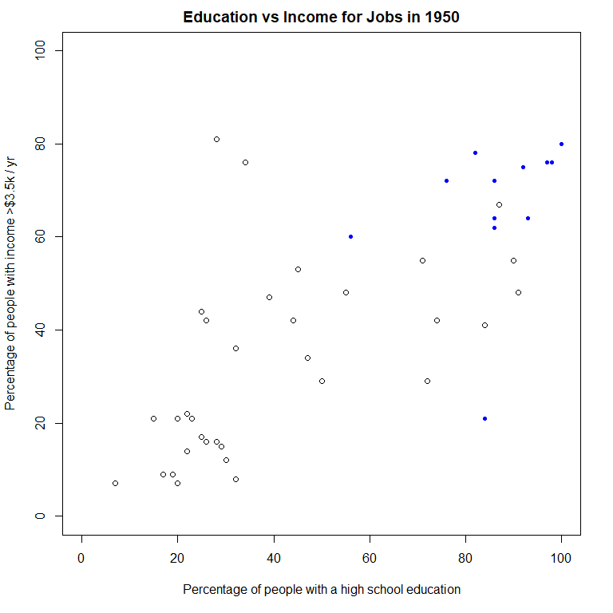

```r
points(
        x[Duncan$prestige > 80],
        y[Duncan$prestige > 80],
        col='blue',
        pch=20
        )
```

#### (ii) Add a legend explaining the differences, then save a $500 \times 500$ pixel .png file

```r
png('../output/8_1_b.png', width=500, height=500)

plot(
    x, y,
    type='n',
    xlim=c(0, 100),
    ylim=c(0, 100),
    xlab='Percentage of people with a high school education',
    ylab='Percentage of people with income >$3.5k / yr',
    main='Education vs Income for Jobs in 1950'
    )

points(
        x[Duncan$prestige <= 80],
        y[Duncan$prestige <= 80],
        col='black',
        pch=1
        )
points(
        x[Duncan$prestige > 80],
        y[Duncan$prestige > 80],
        col='blue',
        pch=20
        )

legend(
    'topleft',
    legend=c('Job prestige \u2264 80%', 'Job prestige > 80%'),
    pch=c(1, 20),
    col=c('black', 'blue'),
    pt.cex=c(2, 2)
)

dev.off()
```

### (c) Create a list called `exer` that contains the three data sets `quakes`, `q5.dframe`, and `Duncan` Then:

```r
exer <- list(quakes=quakes, q5.dframe=q5.dframe, Duncan=Duncan)
```

#### (i) Write the list to disk, called *`Exercise8-1.txt`*

```r
dput(exer, '../output/Exercise8-1.txt')
```

#### (ii) Read *`Exercise8-1.txt`*, call the result `list.of.dataframes`

```r
list.of.dataframes <- dget('../output/Exercise8-1.txt')
names(list.of.dataframes)
```

```
[1] "quakes"    "q5.dframe" "Duncan"
```

### (d) Use `ggsave()` to save a copy of the figure from $\S 7.4.3$ as a *.tiff* file

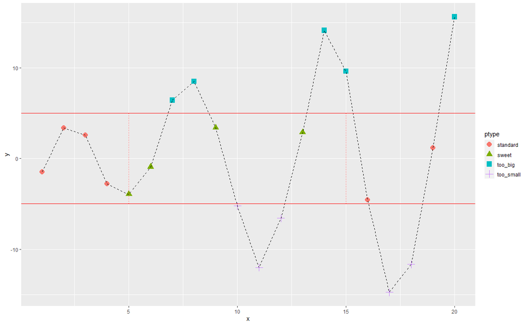

```r
x <- 1:20
y <- c(
        -1.49, 3.37, 2.59, -2.78, -3.94,
        -0.92, 6.43, 8.51, 3.41, -5.23,
        -12.01, -6.58, 2.87, 14.12, 9.63,
        -4.58, -14.75, -11.67, 1.17, 15.62
        )

ptype <- rep(NA, length(x))
ptype[y >= 5] <- 'too_big'
ptype[y <= -5] <-'too_small'
ptype[(x >= 5 & x <= 15) & (y > -5 & y < 5)] <- 'sweet'
ptype[(x < 5 | x > 15) & (y > -5 & y < 5)] <- 'standard'
ptype <- factor(ptype)

(
qplot(x, y, color=ptype, shape=ptype)
+ geom_point(size=4)
+ geom_line(mapping=aes(group=1), color='black', lty=2)
+ geom_hline(mapping=aes(yintercept=c(-5, 5)), color='red')
+ geom_segment(
                mapping=aes(x=5, y=-5, xend=5, yend=5),
                color='red',
                lty=3
                )
+ geom_segment(
                mapping=aes(x=15, y=-5, xend=15, yend=5),
                color='red',
                lty=3
                )
)
```

```r
ggsave(
        filename='../output/Section7-4-3.tiff',
        width=180,
        height=150,
        units='mm'
        )
```